# Classifying with random forests

Jose M Sallan

28/03/2020

```r
library(tidyverse)
```

# 1 Bootstrapping

Random forests is a machine learning technique that applies the concept of bootstrapping. In statistics, bootstrapping is to define a test or metric relying on random sampling with replacement. When we apply bootstrapping we obtain subsamples of the population, so that an element of the population can appear in more than one subset.

To illustrate, let’s define a `set` to bootstrap. The set itself has been defined with sampling with replacement.

```r
set.seed(2020)
set <- sample(1:1000, 100, replace = TRUE)
```

```r
sampling_set <- function(set, n){
  set_size <- length(set)
  elements <- sample(1:set_size, n, replace = FALSE)
  subset <- set[elements]
  return(subset)
}
```

Let’s see how this function obtains a subset of the greater set:

```r
subset <- sampling_set(set, 10)
sort(set)
```

```
##   [1]   1  13  23  29  31  42  43  50  52  56  70  78  95 102 138 141 164
##  [18] 166 170 176 197 200 213 213 214 236 256 259 263 273 285 300 321 322
##  [35] 324 325 336 365 368 374 380 387 403 412 419 431 432 440 461 489 498
##  [52] 500 519 534 537 554 580 588 589 590 594 599 605 610 619 621 623 630
##  [69] 632 635 641 648 664 683 687 710 718 722 724 728 729 744 756 766 786
##  [86] 800 826 834 848 856 863 882 896 900 921 929 941 945 962 994
```

```r
sort(subset)
```

```
##  [1] 365 403 554 590 641 710 766 826 900 941
```

# 2 Classifying with random forests

When applied to classification problems, random forests try to improve the performance of classification algorithms like the obtained with the `C5.0` function, training many different decision trees with random sampling. The name *forest* comes from obtaining many trees in the algorithm. More specifically, we apply random forests for classification as follows:

1. Fix the model variables: the number of trees to train `ntree` and the number of variables to choose in each tree `mtry`.
2. Repeat `ntree` times:
   1. Select `mtry` variables randomly
   2. Train a decision tree with the selected variables.
3. Assign a class to each member of the considered data set using a majority rule.

To clarify the concept of **majority rule**, let’s suppose that the categories on the class variable are *A* and *B*, and that we have trained `ntree=100` trees. For a specific element of the population, 60 trees have classified it as *A* and 40 as *B*. Then, applying the majority rule, the random forest algorithm will assign to the element the category *A*.

Random forests is an example of **meta-learning** algorithms. The idea of meta-learning is combining an **ensemble of weak learners**, to create a stronger learner. Another meta-learning technique is **boosting**, which is implemented in the `C5.0` algorithm of decision trees.

Random forests can be more precise than decision trees, but they take more time to run. Random forests can be adequate for datasets with many variables.

There are many packages implementing random forest and its variants in R. We can access to many of them using `caret`. Here we will use the `randomForest` package to tackle a classification problem in a dataset with many variables.

# 3 The `Sonar` data

The dataset we will analyse is `Sonar`, which is available from the mlbench package.

```r
library(mlbench)
data("Sonar")
```

The task is to train a network to discriminate between sonar signals bounced off a metal cylinder and those bounced off a roughly cylindrical rock. Each of the 208 elements is a set of 60 variables `V1` to `V60` in the range 0.0 to 1.0. Each number represents the energy within a particular frequency band, integrated over a certain period of time. The integration aperture for higher frequencies occurs later in time, since these frequencies are transmitted later during the chirp.

The `Class` category label associated with each element contains the letter *R* if the object is a rock and *M* if it is a mine (metal cylinder). So our work is to try to know if the object detected in an observation is a rock or a mine using the information of the features `V1` to `V60`. The numbers in variable names are in increasing order of aspect angle, but they do not encode the angle directly.

Let’s use `caret` to split the dataset into train and test:

```r
library(caret)
set.seed(2020)
inTrain <- createDataPartition(Sonar$Class, p=0.8, list = FALSE)
Sonar_train <- Sonar[inTrain, ]
Sonar_test <- Sonar[-inTrain, ]
```

# 4 Classifying `Sonar` with random forests

Let’s load the `randomForest` library for random forests.

```r
library(randomForest)
```

Let’s build a random forest model for `Sonar_train`:

```r
set.seed(2020)
Sonar_rf01 <- randomForest(Class ~ ., Sonar_train, ntree=100)
```

Let’s use the `confusionMatrix` function of `caret` to assess algorithm performance on the train set. Note that the output of `randomForest` contains the prediction for the train set:

```r
confusionMatrix(Sonar_rf01$predicted, Sonar_train$Class)
```

```
## Confusion Matrix and Statistics
##
##           Reference
## Prediction  M  R
##          M 81 25
##          R  8 53
##
##                Accuracy : 0.8024
##                  95% CI : (0.7338, 0.8599)
##     No Information Rate : 0.5329
##     P-Value [Acc > NIR] : 3.486e-13
##
##                   Kappa : 0.5976
##
##  Mcnemar's Test P-Value : 0.005349
##
##             Sensitivity : 0.9101
##             Specificity : 0.6795
##          Pos Pred Value : 0.7642
##          Neg Pred Value : 0.8689
##              Prevalence : 0.5329
##          Detection Rate : 0.4850
##    Detection Prevalence : 0.6347
##       Balanced Accuracy : 0.7948
##
##        'Positive' Class : M
##
```

# 5 Random forests with `caret`

The `caret` package has many implementations of the random forest algorithm and its variants. A list of them is in:

https://topepo.github.io/caret/train-models-by-tag.html#Random_Forest

Here we will use the `randomForest` package in `caret` making `method="rf"`. In the tuning grid we will place mtry values from 2 to 10.

```r
control01 <- trainControl(method='repeatedcv',
                        number=5,
                        repeats=3)

rf_grid <- expand.grid(mtry=2:10)
```

Let’s train the model with `ntree=100` for speed.

```r
set.seed(2020)
Sonar_rfCaret01 <- train(Class ~ ., Sonar_train, method="rf", trControl=control01, tuneGrid=rf_grid, ntree=100)
```

Let’s see a plot with the values of accuracy for each element of the tuning grid. The best value is obtained with `mytr=3`.

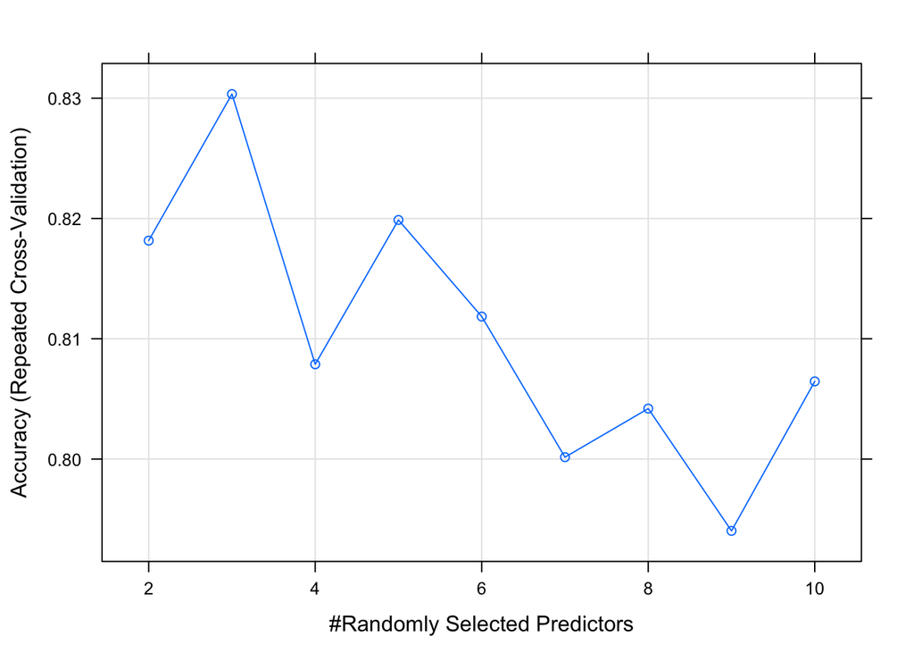

```r
plot(Sonar_rfCaret01)
```

For some reason, the method `rf` in `caret` does not provide adequate predicted values for the training test. Let’s make the predictions on the test set instead:

```r
Sonar_rfCaret01_predict_test <- predict(Sonar_rfCaret01, Sonar_test)
confusionMatrix(Sonar_rfCaret01_predict_test, Sonar_test$Class)
```

```
## Confusion Matrix and Statistics
##
##           Reference
## Prediction  M  R
##          M 20  7
##          R  2 12
##
##                Accuracy : 0.7805
##                  95% CI : (0.6239, 0.8944)
##     No Information Rate : 0.5366
##     P-Value [Acc > NIR] : 0.001099
##
##                   Kappa : 0.5505
##
##  Mcnemar's Test P-Value : 0.182422
##
##             Sensitivity : 0.9091
##             Specificity : 0.6316
##          Pos Pred Value : 0.7407
##          Neg Pred Value : 0.8571
##              Prevalence : 0.5366
##          Detection Rate : 0.4878
##    Detection Prevalence : 0.6585
##       Balanced Accuracy : 0.7703
##
##        'Positive' Class : M
##
```

# 6 Training for a specific metric

```r
control2 <- trainControl(method='repeatedcv',
                         number=5,
                         repeats=3, summaryFunction = twoClassSummary, classProbs = TRUE)
```

And now we train a new model telling `caret` to optimize sensitivity:

```r
set.seed(2020)
Sonar_rfCaret02 <- train(Class ~ ., Sonar_train, method="rf", trControl=control2, tuneGrid=rf_grid, metric="Sens")
```

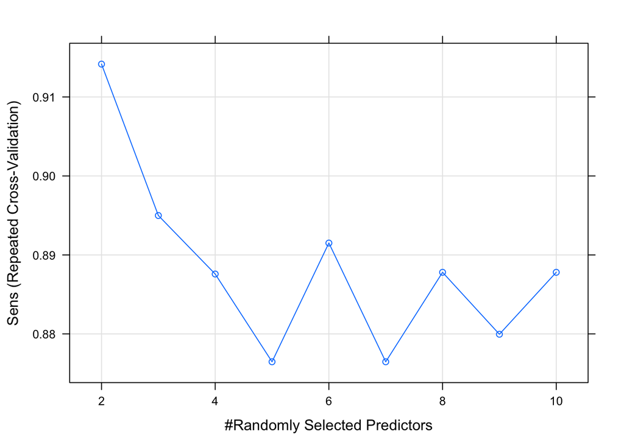

```r
plot(Sonar_rfCaret02)
```

Here are the results of applying this new model to the test set. We see that we get the same value of sensitivity than in the previous model, so that we cannot go further than that value for this model and this dataset. Note that the value of accuracy is smaller than in the previous model.

```r
Sonar_rfCaret02_predict_test <- predict(Sonar_rfCaret02, Sonar_test)
confusionMatrix(Sonar_rfCaret02_predict_test, Sonar_test$Class)
```

```
## Confusion Matrix and Statistics
##
##           Reference
## Prediction  M  R
##          M 20  9
##          R  2 10
##
##                Accuracy : 0.7317
##                  95% CI : (0.5706, 0.8578)
##     No Information Rate : 0.5366
##     P-Value [Acc > NIR] : 0.008409
##
##                   Kappa : 0.4466
##
##  Mcnemar's Test P-Value : 0.070440
##
##             Sensitivity : 0.9091
##             Specificity : 0.5263
##          Pos Pred Value : 0.6897
##          Neg Pred Value : 0.8333
##              Prevalence : 0.5366
##          Detection Rate : 0.4878
##    Detection Prevalence : 0.7073
##       Balanced Accuracy : 0.7177
##
##        'Positive' Class : M
##
```

# 7 Variable importance in random forests

In random forest models, we can obtain information about the role of features or independent variables in prediction. There are two metrics for this:

- **minimal depth:** in classification trees, we consider first the most influential variables to split the data. The minimal depth of a variable is equal to the first time the variable is used to split the tree. As each variable can behave differently in each trained tree, we have a minimal depth distribution for each variable.
- **variable importance:** the variable importance in a classification tree is calculated considering the average incrase in node purity a split in that variable causes. Again, we will have a value of variable importance for each tree, and a distribution of node importance.

All these metrics can be obtained with the `randomForestExplainer` package:

```r
library(randomForestExplainer)
```

A beautiful vignette explaining this package (and explaining random forests, too) can be found at:

https://cran.rstudio.com/web/packages/randomForestExplainer/vignettes/randomForestExplainer.html

```r
Sonar_rf02 <- randomForest(Class ~ ., Sonar_train, ntree=1000, localImp=TRUE)
```

Let’s start examining minimal depth:

```r
min_depth_frame_rf02 <- min_depth_distribution(Sonar_rf02)
min_depth_frame_rf02 %>% top_n(10)
```

```
##    tree variable minimal_depth
## 1    14      V58             9
## 2    87      V35             9
## 3   102      V55             9
## 4   155      V29             9
## 5   175      V39             9
## 6   192      V19             9
## 7   238      V31             9
## 8   263      V24             9
## 9   422       V8             9
## 10  530      V15             9
## 11  533      V38             9
## 12  650      V12             9
## 13  656      V53             9
## 14  676       V8             9
```

[output cut: 17 more lines]

In `min_depth_frame_rf02` we have the minimal depth of each variable, for each trained tree. A nice way to examine minimal depth is with a plot. The number of variables to plot can be controlled with the `k` parameter.

[figure not shown]

```r
plot_min_depth_distribution(min_depth_frame_rf02)
```

For more elements of variable importance analysis, you can go to:

https://cran.rstudio.com/web/packages/randomForestExplainer/vignettes/randomForestExplainer.html